# Apresentação ggplot2 e lattice

Alunos: Pedro, Victor e David

## Introdução ao ggplot2

ggplot2 é uma biblioteca do R que permite criar, declarativamente, gráficos e customizá-los. Com dados e variáveis para serem mapeadas, o ggplot2 cuida do restante do gráfico, deixando opções estéticas a cargo do programador.

ggplot2 é considerada a biblioteca mais elegante para criação de gráficos disponível em R. A seguir, vamos mostrar uma breve introdução ao ggplot2, mostrando alguns recursos e como customizar os gráficos.

O primeiro passo, naturalmente, é instalar e importar a biblioteca.

Para essa introdução, usaremos a base de dados que já vem embutida ao ggplot2, chamada midwest.

```r
options(scipen=999) # Desliga a notação científica
data("midwest", package = "ggplot2")
head(midwest, n = 5) # Mostrando as primeiras 5 linhas
```

```
## # A tibble: 5 x 28
##     PID county state  area poptotal popdensity popwhite popblack
##   <int> <chr>  <chr> <dbl>    <int>      <dbl>    <int>    <int>
## 1   561 ADAMS  IL    0.052    66090      1271.    63917     1702
## 2   562 ALEXA~ IL    0.014    10626       759      7054     3496
## 3   563 BOND   IL    0.022    14991       681.    14477      429
## 4   564 BOONE  IL    0.017    30806      1812.    29344      127
## 5   565 BROWN  IL    0.018     5836       324.     5264      547
## # ... with 20 more variables: popamerindian <int>, popasian <int>,
## #   popother <int>, percwhite <dbl>, percblack <dbl>, percamerindan <dbl>,
## #   percasian <dbl>, percother <dbl>, popadults <int>, perchsd <dbl>,
## #   percollege <dbl>, percprof <dbl>, poppovertyknown <int>,
## #   percpovertyknown <dbl>, percbelowpoverty <dbl>,
## #   percchildbelowpovert <dbl>, percadultpoverty <dbl>,
## #   percelderlypoverty <dbl>, inmetro <int>, category <chr>
```

#### Criando um gráfico básico

Chamaremos a função ggplot, diremos o dataframe, os eixos e o tipo do gráfico.

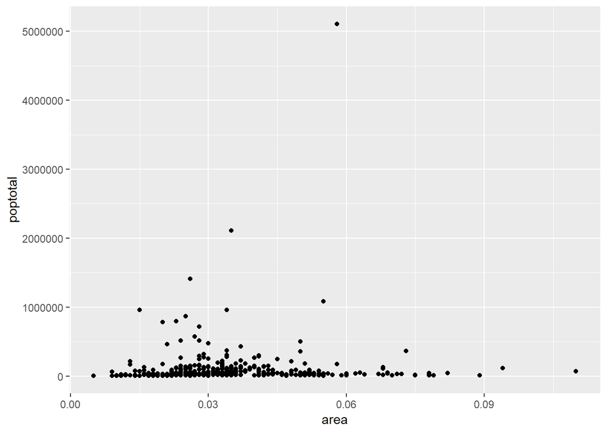

```r
ggplot(midwest, aes(x=area, y=poptotal)) + geom_point()
```

Compare com o mesmo gráfico com o R base.

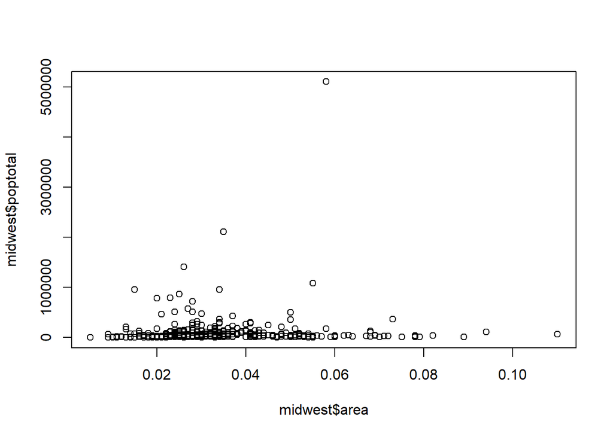

Podemos ver que o gráfico com ggplot2 saiu muito melhor. Mesmo assim, ainda há problemas com ele. Não está claro o que ele quer dizer. Não há títulos, legendas e ele ainda não está muito bonito.

Vamos dar alguns passos para melhor a visualização das informações. Primeiro, vamos adicionar uma linha e sem seguida vamos dar um zoom no gráfico, para melhorar a visualização.

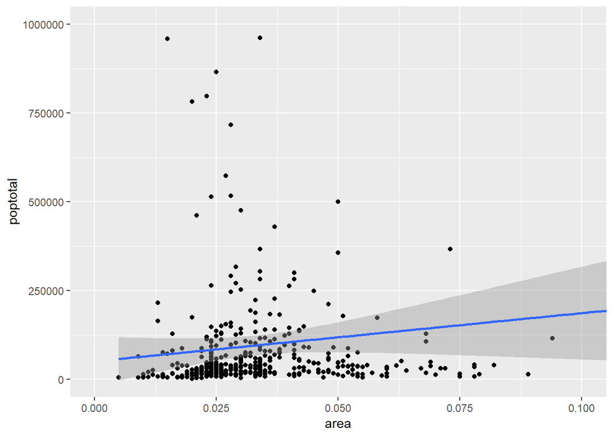

Ficou um pouco melhor, mas ainda podemos melhorar. Vamos adicionar um título e renomear os eixos.

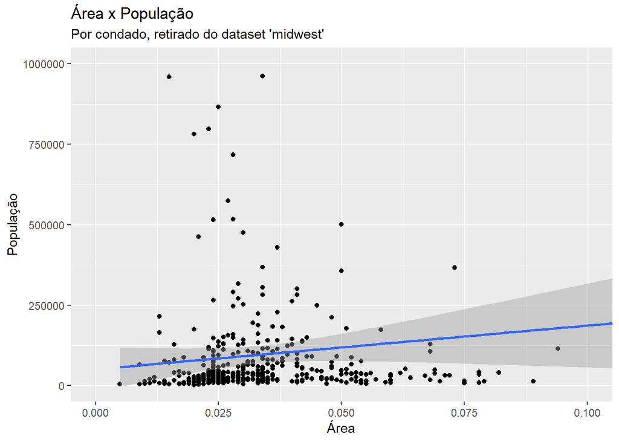

Podemos customizar o gráfico, mudando a cor da linha e a cor dos pontos, além do tamanho dos pontos.

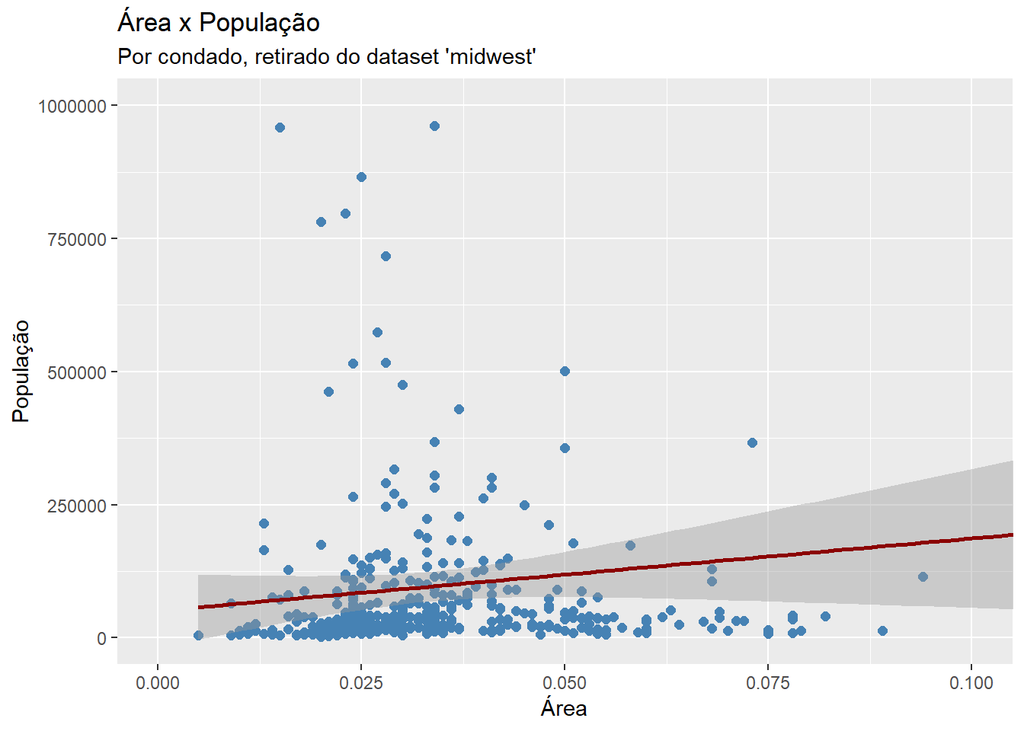

No entanto, podemos deixar a visualização ainda mais interessante. E se as cores dos pontos representassem uma coluna do dataframe? Isso é possível de fazer da seguinte forma:

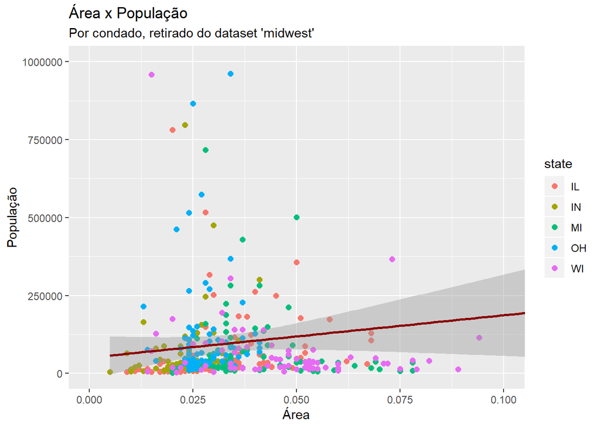

Muito melhor! Agora, podemos colocar um fundo branco da seguinte forma:

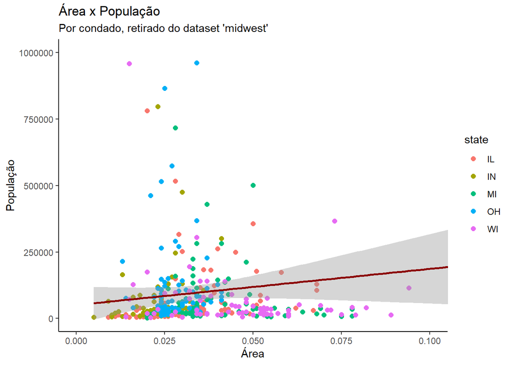

Assim, vimos algumas funções básicas do ggplot2 e verificamos o ponto forte da biblioteca, que é a criação de gráficos de uma maneira simples e bonita.

## Introdução ao Lattice

o Lattice é um importante pacote de analise gráfica que antecedeu o ggplot2. Útil para preparar painéis com gráficos de forma automatizada. Combinado com a leitura automática de arquivos de dados, torna a repetitiva visualização de dados e preparação de gráficos muito eficiente.

Instalando e carregando o pacote lattice

```
## starting httpd help server ... done
```

Para os exemplos será usada a base “Cars93”

```
##   Manufacturer   Model    Type Min.Price Price Max.Price MPG.city
## 1        Acura Integra   Small      12.9  15.9      18.8       25
## 2        Acura  Legend Midsize      29.2  33.9      38.7       18
## 3         Audi      90 Compact      25.9  29.1      32.3       20
## 4         Audi     100 Midsize      30.8  37.7      44.6       19
## 5          BMW    535i Midsize      23.7  30.0      36.2       22
##   MPG.highway            AirBags DriveTrain Cylinders EngineSize
## 1          31               None      Front         4        1.8
## 2          25 Driver & Passenger      Front         6        3.2
## 3          26        Driver only      Front         6        2.8
## 4          26 Driver & Passenger      Front         6        2.8
## 5          30        Driver only       Rear         4        3.5
##   Horsepower  RPM Rev.per.mile Man.trans.avail Fuel.tank.capacity
## 1        140 6300         2890             Yes               13.2
## 2        200 5500         2335             Yes               18.0
## 3        172 5500         2280             Yes               16.9
## 4        172 5500         2535             Yes               21.1
## 5        208 5700         2545             Yes               21.1
##   Passengers Length Wheelbase Width Turn.circle Rear.seat.room
## 1          5    177       102    68          37           26.5
## 2          5    195       115    71          38           30.0
## 3          5    180       102    67          37           28.0
## 4          6    193       106    70          37           31.0
## 5          4    186       109    69          39           27.0
##   Luggage.room Weight  Origin          Make
## 1           11   2705 non-USA Acura Integra
## 2           15   3560 non-USA  Acura Legend
## 3           14   3375 non-USA       Audi 90
## 4           17   3405 non-USA      Audi 100
## 5           13   3640 non-USA      BMW 535i
```

#### Criando um gráfico básico

O gráfico é preparado com o comando básico xyplot. No comando os dados MPG.city são plotados versus EngineSize através da expressão “MPG.city ~ EngineSize” para o conjunto de dados total Cars93.

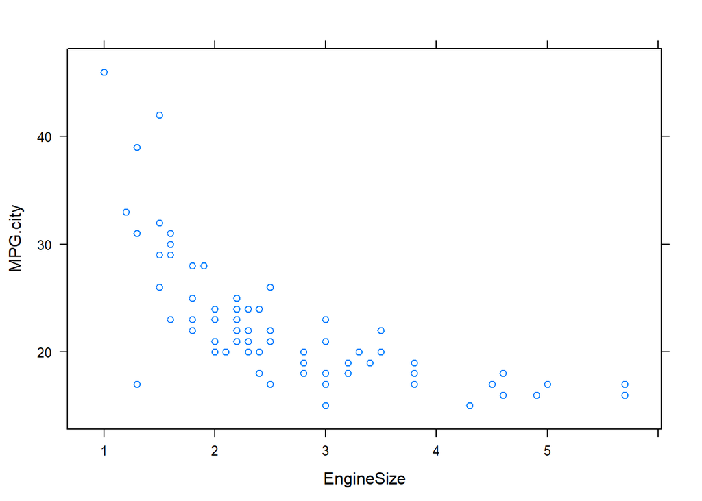

Outros comandos disponíveis são barchart, bwplot, densityplot, dotplot, histogram, etc.

#### Selecionando dados a serem plotados

Dados São selecionados através da função subset

```
##    Manufacturer      Model    Type Min.Price Price Max.Price MPG.city
## 12    Chevrolet   Cavalier Compact       8.5  13.4      18.3       25
## 13    Chevrolet    Corsica Compact      11.4  11.4      11.4       25
## 14    Chevrolet     Camaro  Sporty      13.4  15.1      16.8       19
## 15    Chevrolet     Lumina Midsize      13.4  15.9      18.4       21
## 16    Chevrolet Lumina_APV     Van      14.7  16.3      18.0       18
##    MPG.highway            AirBags DriveTrain Cylinders EngineSize
## 12          36               None      Front         4        2.2
## 13          34        Driver only      Front         4        2.2
## 14          28 Driver & Passenger       Rear         6        3.4
## 15          29               None      Front         4        2.2
## 16          23               None      Front         6        3.8
##    Horsepower  RPM Rev.per.mile Man.trans.avail Fuel.tank.capacity
## 12        110 5200         2380             Yes               15.2
## 13        110 5200         2665             Yes               15.6
## 14        160 4600         1805             Yes               15.5
## 15        110 5200         2595              No               16.5
## 16        170 4800         1690              No               20.0
##    Passengers Length Wheelbase Width Turn.circle Rear.seat.room
## 12          5    182       101    66          38           25.0
## 13          5    184       103    68          39           26.0
## 14          4    193       101    74          43           25.0
## 15          6    198       108    71          40           28.5
## 16          7    178       110    74          44           30.5
##    Luggage.room Weight Origin                 Make
## 12           13   2490    USA   Chevrolet Cavalier
## 13           14   2785    USA    Chevrolet Corsica
## 14           13   3240    USA     Chevrolet Camaro
## 15           16   3195    USA     Chevrolet Lumina
## 16           NA   3715    USA Chevrolet Lumina_APV
```

#### Diferentes painéis

O lattice aparece de forma importante quando precisamos de gráficos com maiores detalhes, separados de acordo com outros fatores. Em vez de plotar tudo junto como no gráfico acima, a mesma informação pode ser plotada de forma separada por fabricante (Manufacturer), usando o símbolo “|”.

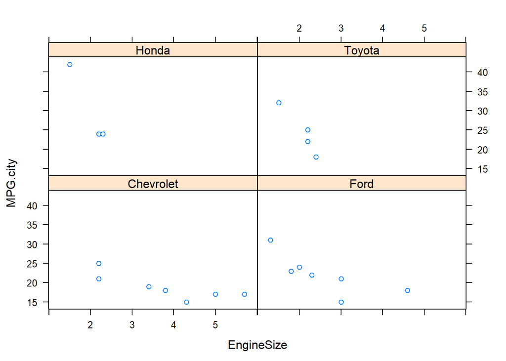

Podemos separar os dados ainda mais, por exemplo, por tipo de carro (“Type”) usando a opção group. A função auto.key, que adiciona a legenda.

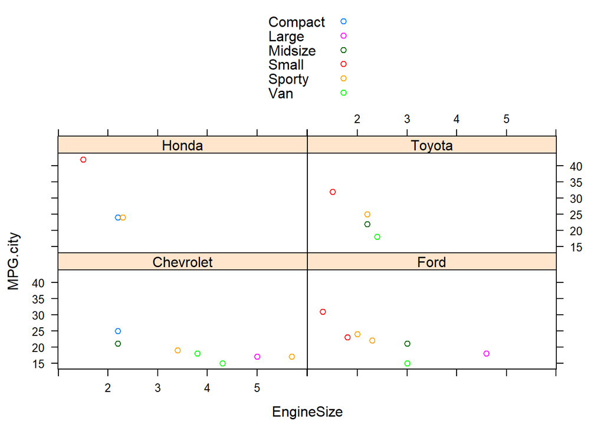

#### Níveis de classificação

A fórmula da função xyplot abaixo apresenta o rendimento do carro (MPG.city) versus tamanho do motor (EngineSize) de acordo com o tamanho do carro e dividido entre carros produzidos dentro e fora dos EUA, por número de passageiros.

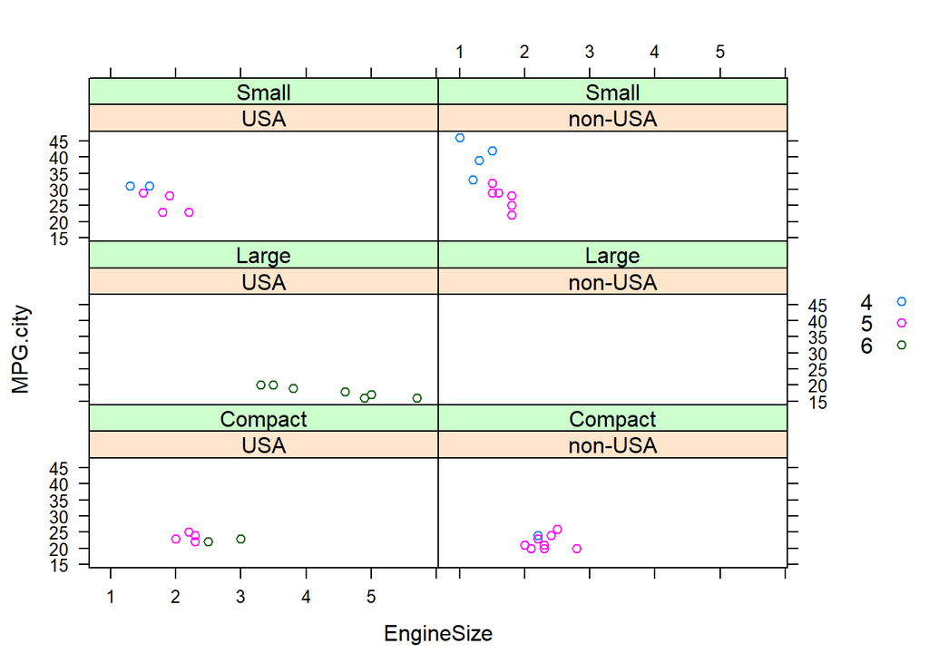

#### Legenda

A legenda pode ser colocada em lugar mais apropriado.

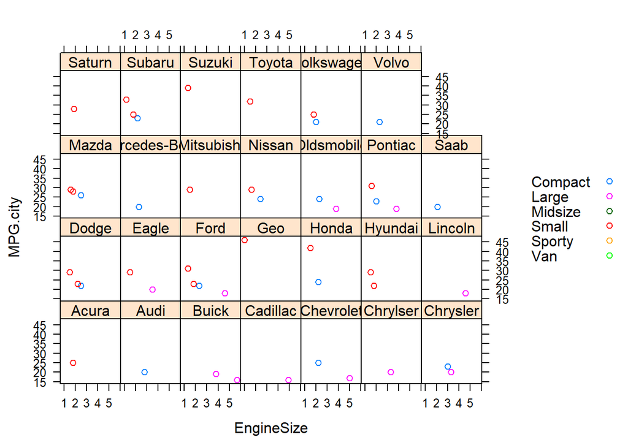

#### Título e nome dos eixos

Para colocar um título no gráfico e mudar o nome dos eixos, use respectivamente main, xlab e ylab:

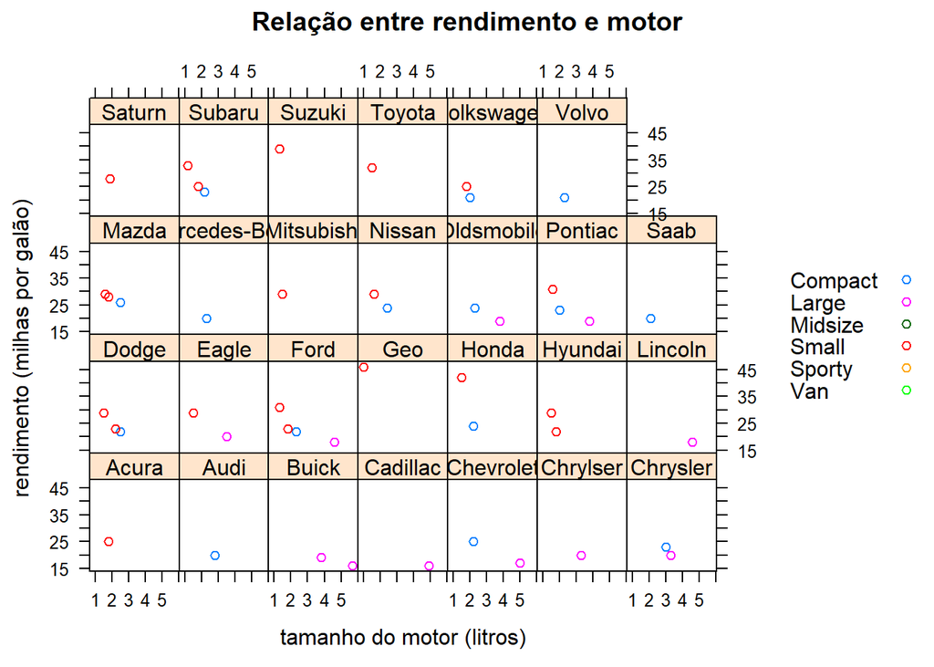

#### Tipo de gráfico

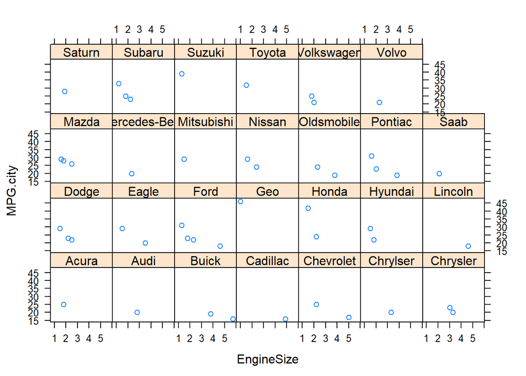

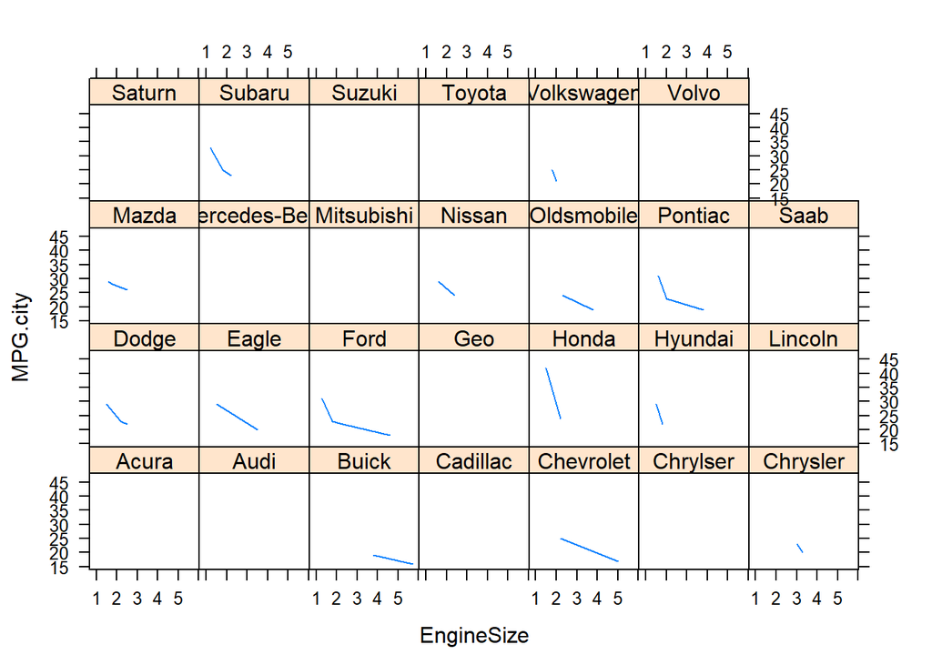

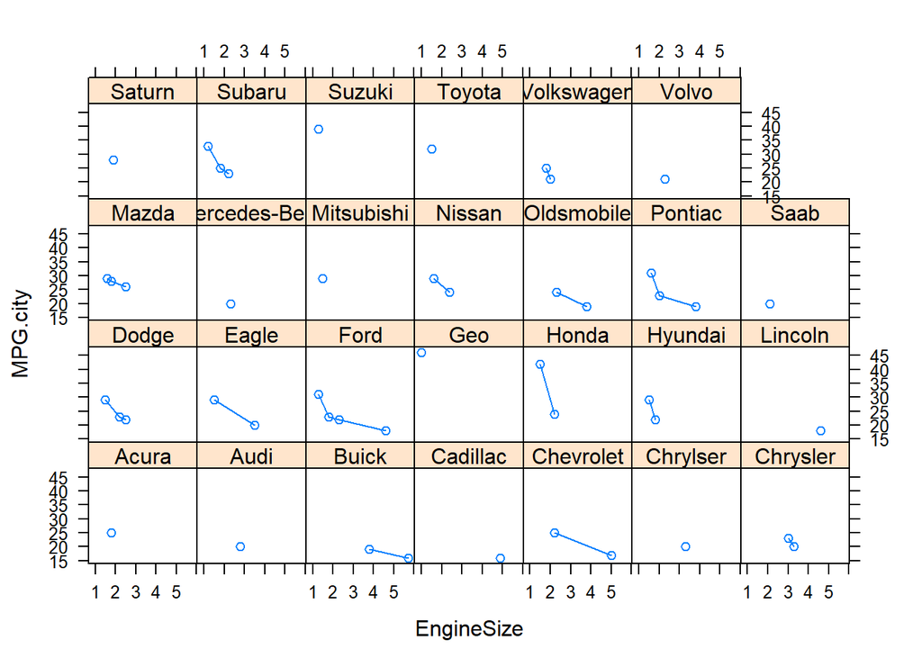